# motifActivity: reconstruct transcription factor networks from high-throughput data and sequence information

2021-11-24

```r
source("/home/kwreczy/projects/motifActivity/R/SignalMatrix.R")
```

```
## in method for 'getSignalMatrix' with signature '"TabixFile","GRanges","character","character","numeric"': no definition for class "TabixFile"
```

```r
source("/home/kwreczy/projects/motifActivity/R/Model.R")
source("/home/kwreczy/projects/motifActivity/R/Visualise.R")
source("/home/kwreczy/projects/motifActivity/R/CorrelateMotifswithGenes.R")
source("/home/kwreczy/projects/motifActivity/R/MotifHitsMatrix.R")
```

# 1 Introduction

In this manual, I will show how to use the `motifActivity` package. `motifActivity` is an R package for a reconstruction of transcription factor networks by using DNA motif activity estimated from high-throughput sequencing data and sequence information. The package is designed to deal with sequencing data from Bisulfite-seq, ATAC-seq, ChIP-seq, RNA-seq and its variants.

## 1.1 Computational integration of epigenetic data with other types for genomic data

Transcription factors (TFs) bind to specific, relatively short DNA sequences called DNA sequence motifs. The binding sites of TFs can be determined genome-wide using chromatin immunoprecipitation with specific antibodies followed by high-throughput sequencing (ChIP-seq). Although ChIP-seq studies suggest that many TF binding events appear to be not functional or are associated with secondary DNA structures (Wreczycka et al. 2019), the presence of a sequence motif is predictive of the binding events and gene expression (Lambert et al. 2018).

A powerful system-level integrative approach is to exploit association of epigentic signals at regulatory regions with transcription factor binding to infer patterns of regulatory activity. This association is usually not straigh-forward, such as in case of DNA methylation. Although DNA methylation at regulatory sites has been traditionally viewed as dictating transcription factor affinity, the opposite has also been observed (Stadler et al. 2011). Moreover, there are classes of TFs (for example POU and NFAT families) that prefer binding to methylated sequences (Yin et al. 2017). Here, in this manual, I will describe methods for association of DNA methylation with transcription factor binding patterns, but it can be extended to any other epigenetic or genetic signal.

First generation of methods to predict transcription factors involved in particular transcriptional response utilize Position Probability Matrices (PWMs) of TFs motifs to predict binding sites in enhancers in the vicinity of regulated genes (Dhaeseleer 2006). These methods range from simple PWM matching (Kel et al. 2003; Tan and Lenhard 2016; Grant, Bailey, and Noble 2011; Gama-Castro et al. 2016; Heinz et al. 2010) to modeling-based approaches (Zhong, He, and Bar-Joseph 2013; Jankowski, Tiuryn, and Prabhakar 2016). Another approach is transcription factor enrichment analysis (TFEA)(Rubin et al. 2020) that draws inspiration from Gene Set Enrichment Analysis (GSEA)(Subramanian et al. 2005), and detects positional motif enrichment within a list of ranked regions of interest, such as enhancers. Still, the identification of key transcription factors in regulatory networks by only motif enrichment methods is generally associated with a high false-positive rate with too many candidate factors to investigate.

## 1.2 Modelling-based approaches of integrating epigenetic data

[figure not shown]

Figure 1. (A) Schematic representation of transcription factors binding to their DNA motifs in a genomic region $1$, and in conditions $1$ to $s$. On Y axis is depicted DNA methylation percentage. (B) Schematic representation of the model for condition 1 used in (Piotr J Balwierz et al. 2014; Madsen et al. 2018; Lederer et al. 2020). (C) The model is used to explain the signal levels $E_{gs}$ in terms of bindings sites $N_{gm}$ and unknown motif activities $A_{ms}$, which are inferred by the model. Results might include (D) creating motif activity profiles, (E) correlation of motif activity profiles with gene expression, (F) based on result TFs creating PPI networks using the STRING database (Szklarczyk et al. 2018).

In several studies, linear regression-based approach have been applied, in which the sequence information is used to model gene expression or chromatin marks, and to learn the TFs that play a major role in gene regulation (T. F. Consortium and Center 2009; Balwierz et al. 2014; Osmanbeyoglu et al. 2014). The multivariate linear model represents the signal expression of data as a linear combination of motif scores (motif occurrences) and their influential weights (“motif activities”) (Figure 1A-C). Due to the large number of genes the weights are generally highly significant and they can be interpreted as a proxy for TFs activities. The error or noise term in the model represents all signal that cannot be explained by the model, i.e. the linear combination of the motif activity scores. More recent approaches use linear regression with L2-regularization (Ridge Regression) (Madsen et al. 2018), Bayesian Ridge Regression (Balwierz et al. 2014) or Bayesian Linear Mixed Models (Lederer et al. 2020). Bayesian Linear Mixed Models approach relaxes the rigid independence between samples, however on real biological data, it does not perform better than the Bayesian Ridge Regression method due to the fact that large fraction of the gene expression signal ends up in the noise term of the model (Lederer et al. 2020).

## 1.3 System-level approaches of integrating epigenetic data

Another set of integrative algorithms are tailored for integrating DNA methylation data that are generated in conjunction with other data types from the same samples: for instance, this may include sequence information, mutations, copy-number variants, mRNA, microRNAs and protein expression. Performing simultaneous inference using all data types together offers more powerful and unbiased framework to reveal system-level associations and extract novel biological insights. These categories of methods are particularly viable and flexible because any data can be ingested as long as they can be represented as a generic matrix of values. As an example, a joint NMF algorithm was applied to the matched DNA methylation, mRNA and miRNA expression data sets for ovarian cancer from The Cancer Genome Atlas (TCGA), revealing novel perturbed pathways (Zhang et al. 2012). Other matrix factorization methods include iCluster (Shen, Olshen, and Ladanyi 2009) that performed integrative DNA methylation and mRNA analysis of oestrogen receptor (ER)+ breast cancer, and MOFA (Argelaguet et al. 2018, 2020). Another powerful method based on deep learning is Janggu (Kopp et al. 2020) and Multi-omics Autoencoder Integration (maui) (Ronen, Hayat, and Akalin 2019) that gives deep learning’s applicability in deconvoluting non-linear relationships in large datasets using a flexible model architecture. However, these algorithms are usually not tailored for small number of input data points (such as small cohorts of patient data) due to over-fitting, and for that regression-based methods can be more suitable.

# 2 Data

## 2.1 DNA motif database

In order to calculate number of motif occurrences in our target regulatory regions we need a list of PWM matrices of DNA motifs. Here, we use The JASPAR database (Sandelin et al. 2004) as a source of PWM matrices of known DNA motifs, and that can be loaded by using the **MotifDb** R package.

```
## $`Hsapiens-JASPAR_CORE-TFAP2A-MA0003.1`
##   1 2 3         4         5         6          7          8          9
## A 0 0 0 0.1189189 0.1027027 0.2972973 0.28648649 0.10270270 0.04864865
## C 0 1 1 0.3837838 0.3081081 0.2378378 0.16216216 0.08648649 0.42162162
## G 1 0 0 0.2486486 0.3297297 0.3621622 0.49189189 0.74054054 0.42702703
## T 0 0 0 0.2486486 0.2594595 0.1027027 0.05945946 0.07027027 0.10270270
##
## $`Hsapiens-JASPAR_CORE-NR2F1-MA0017.1`
##           1          2          3         4 5         6         7          8
## A 0.0000000 0.07692308 0.92307692 0.4615385 0 0.0000000 0.0000000 0.07692308
## C 0.0000000 0.00000000 0.00000000 0.5384615 1 0.2307692 0.1538462 0.00000000
## G 0.1538462 0.92307692 0.07692308 0.0000000 0 0.0000000 0.0000000 0.00000000
## T 0.8461538 0.00000000 0.00000000 0.0000000 0 0.7692308 0.8461538 0.92307692
##           9        10         11         12        13        14
## A 0.1538462 0.4615385 0.46153846 0.07692308 0.2307692 0.0000000
## C 0.0000000 0.3076923 0.38461538 0.76923077 0.4615385 0.2307692
## G 0.8461538 0.2307692 0.07692308 0.07692308 0.0000000 0.2307692
## T 0.0000000 0.0000000 0.07692308 0.07692308 0.3076923 0.5384615
##
## $`Hsapiens-JASPAR_CORE-E2F1-MA0024.1`
##   1 2 3   4   5 6 7   8
## A 0 0 0 0.0 0.0 0 0 0.0
## C 0 0 0 0.4 0.2 1 0 0.9
## G 0 0 0 0.6 0.8 0 1 0.1
## T 1 1 1 0.0 0.0 0 0 0.0
```

## 2.2 Target and background regions

```r
# Load differentially methylated regions between high-risk and low-risk patient samples
# and enhancers from neuroblastoma cell lines
load("/home/kwreczy/projects/motifActivity/data/motifActivity_DMRs_enhancers_GPL13534pheno_NBbeta_gene.expr.RData")

target.regions=dmrs.dmrcate$MNA
enh=enhancers$enhancer.nb.cl.mycnamp
bg.regions = enh[-queryHits(findOverlaps(enh,
                                          dmrs.dmrcate$MNA))]

print(target.regions)
```

```
## GRanges object with 410 ranges and 8 metadata columns:
##         seqnames              ranges strand |   no.cpgs min_smoothed_fdr
##            <Rle>           <IRanges>  <Rle> | <integer>        <numeric>
##     [1]     chr7   19182017-19185407      * |        20      0.00000e+00
##     [2]     chr2   71131201-71134936      * |        16      0.00000e+00
##     [3]    chr17     4801965-4807758      * |        22      0.00000e+00
##     [4]     chr5 140796240-140803130      * |        34     7.68315e-185
##     [5]     chr7     8479893-8483710      * |        18     9.52097e-271
##     ...      ...                 ...    ... .       ...              ...
##   [406]     chr2 240174613-240174659      * |         3      3.68279e-21
##   [407]     chr4 188097683-188097967      * |         3      1.49892e-20
##   [408]    chr17   47967818-47968352      * |         3      1.42554e-19
##   [409]     chr1   19110734-19110978      * |         3      7.92827e-19
##   [410]     chr6   85824168-85824216      * |         3      8.45664e-14
##             Stouffer       HMFDR       Fisher   maxdiff  meandiff
```

[output cut: 27 more lines]

```r
print(bg.regions)
```

```
## GRanges object with 140737 ranges and 1 metadata column:
##            seqnames            ranges strand |     score
##               <Rle>         <IRanges>  <Rle> | <numeric>
##        [1]     chr1     540499-540951      * |         3
##        [2]     chr1     712999-715451      * |        10
##        [3]     chr1     761249-763151      * |        10
##        [4]     chr1     766649-768101      * |         4
##        [5]     chr1     768549-769851      * |         3
##        ...      ...               ...    ... .       ...
##   [140733]     chrY 22683849-22689651      * |         4
##   [140734]     chrY 22720899-22723251      * |         3
##   [140735]     chrY 22735599-22740151      * |         5
##   [140736]     chrY 23763349-23765701      * |         3
##   [140737]     chrY 28555399-28557101      * |         3
##   -------
##   seqinfo: 24 sequences from an unspecified genome; no seqlengths
```

## 2.3 Genome annotation

A `BSgenome` object of genome annotation needs to be provided for finding matching DNA motifs within target and background sequences.

```
## Human genome:
## # organism: Homo sapiens (Human)
## # genome: hg19
## # provider: UCSC
## # release date: June 2013
## # 298 sequences:
## #   chr1                  chr2                  chr3
## #   chr4                  chr5                  chr6
## #   chr7                  chr8                  chr9
## #   chr10                 chr11                 chr12
## #   chr13                 chr14                 chr15
## #   ...                   ...                   ...
## #   chr19_gl949749_alt    chr19_gl949750_alt    chr19_gl949751_alt
## #   chr19_gl949752_alt    chr19_gl949753_alt    chr20_gl383577_alt
## #   chr21_gl383578_alt    chr21_gl383579_alt    chr21_gl383580_alt
## #   chr21_gl383581_alt    chr22_gl383582_alt    chr22_gl383583_alt
## #   chr22_kb663609_alt
## # (use 'seqnames()' to see all the sequence names, use the '$' or '[[' operator
## # to access a given sequence)
```

# 3 Example workflow for methylation array data

## 3.1 Get scores within target regions

```r
# get the 450k annotation data
library(IlluminaHumanMethylation450kanno.ilmn12.hg19)
ann450k = getAnnotation(IlluminaHumanMethylation450kanno.ilmn12.hg19)
ann450k.gr = makeGRangesFromDataFrame(ann450k,
                                      start.field="pos",
                                      end.field="pos",
                                      keep.extra.columns=FALSE)


signal.list=mclapply(1:length(target.regions), function(i){
  tr.cpgids = names(subsetByOverlaps(ann450k.gr, target.regions[i]))
  colMeans(NB.beta[which(rownames(NB.beta) %in% tr.cpgids),])
}, mc.cores=20)
signal.ma=matrix(unlist(signal.list),
       ncol = ncol(NB.beta),
       byrow = TRUE)
colnames(signal.ma) = colnames(NB.beta); rownames(signal.ma) = 1:nrow(signal.ma)
colnames(signal.ma) <- sapply(colnames(signal.ma), function(x) strsplit(x, "_")[[1]][1])
print(signal.ma[1:3, 1:3])
```

```
##   GSM1896914 GSM1896915 GSM1896916
## 1  0.1364608  0.0959392  0.1508199
## 2  0.2576389  0.2245392  0.2444934
## 3  0.2176579  0.4332213  0.2819055
```

```r
# filter
fil.gene.sign.mtx =
    filterSignalMatrix(signal.ma,
                       target.regions,
                       gene.expr,
                       corr.method="spearman",
                       species="hg19",
                       rule="basalPlusExt",
                       plot = FALSE,
                       cores=1)
target.regions.fil=fil.gene.sign.mtx$signal.granges
score.mtx.fil=fil.gene.sign.mtx$SignalMatrix
print(dim(score.mtx.fil))
```

```
## [1]  27 105
```

```r
print(score.mtx.fil[1:3,1:3])
```

```
##    GSM1896914 GSM1896915 GSM1896916
## 19  0.7769049 0.70280958  0.6904678
## 20  0.2263176 0.74914477  0.2301950
## 30  0.1930966 0.09482917  0.2260064
```

## 3.2 Get occurences of DNA motifs

First, we calculate number of occurrences of DNA motifs in given target regions. For that, the `getMotifsHits` function uses **motifcounter** functionality that provides motif enrichment based on position frequency matrices. The main feature of **motifcounter** includes the utilization of higher-order background models and accounting for self-overlapping motif matches when determining motif enrichment. It can be particularly useful when analyzing differentially methylated regions rich in GC sequences. The background model allows to capture dinucleotide (or higher-order nucleotide, such as here in the example order of 3) composition adequately which may reduced model biases and misleading results compared to using simple GC background models.

```r
motifhits = getMotifsHits(motifs,
                          target.regions,
                          bg.regions,
                          normalize=TRUE,
                          singlestranded=FALSE,
                          cores=5,
                          genome=genome,
                          order=3,
                          alpha=0.005,
                          gran=0.05)
```

```
## Getting signal sequences..
```

```
## Getting background sequences..
```

```
## Estimate a background model..
```

```
## Calculate number of motifs hits in given input sequences..
```

```r
print(motifhits[1:3, 1:3])
```

```
##      Hsapiens-JASPAR_CORE-TFAP2A-MA0003.1 Hsapiens-JASPAR_CORE-NR2F1-MA0017.1
## [1,]                                   81                                 141
## [2,]                                   48                                  29
## [3,]                                   56                                  11
##      Hsapiens-JASPAR_CORE-E2F1-MA0024.1
## [1,]                                308
## [2,]                                 27
## [3,]                                 73
```

## 3.3 Running a model

In several studies, linear regression-based approach have been applied, in which the sequence information is used to model gene expression or chromatin marks, and to learn the TFs that play a major role in gene regulation (T. F. Consortium and Center 2009; Balwierz et al. 2014; Osmanbeyoglu et al. 2014; Madsen et al. 2018; Lederer et al. 2020). In these models the multivariate linear model represents the signal expression of data as a linear combination of motif scores (motif occurrences) and their influential weights (“motif activities”) (Figure 1A-C). In our case, we simply used ranked regression.

In our example workflow, motif activity refers to beta coefficients of the model ($A_{ms}$ variable in the Figure 1C); for example, if a beta coefficient is negative it means that for every one unit increase in the prediction variable (number of DNA motifs occurrences) the outcome variable (average % DNA methylation on DMRs) decreases by the coefficient value. Therefore, in case of TFs that bind to unmethylated or lowly methylated regions, we are interested in negative values of motif activity. In addition, motif activity between subgroups of samples might and should be different (in our example, low motif activity values for high-risk groups and high values for low-risk groups).

```r
model=getModel(signal.ma,
               motifhits,
               cores=1,
               transform.meth=TRUE)
print(model$coef[1:3, 1:3])
```

```
##                                       GSM1896914   GSM1896915    GSM1896916
## Hsapiens-JASPAR_CORE-TFAP2A-MA0003.1  0.01443527 -0.002560228  0.0041230045
## Hsapiens-JASPAR_CORE-NR2F1-MA0017.1  -0.01145814 -0.006110253  0.0005927226
## Hsapiens-JASPAR_CORE-E2F1-MA0024.1   -0.01238944  0.004678543 -0.0008934436
```

## 3.4 Creating a transcription factor networks and visualization

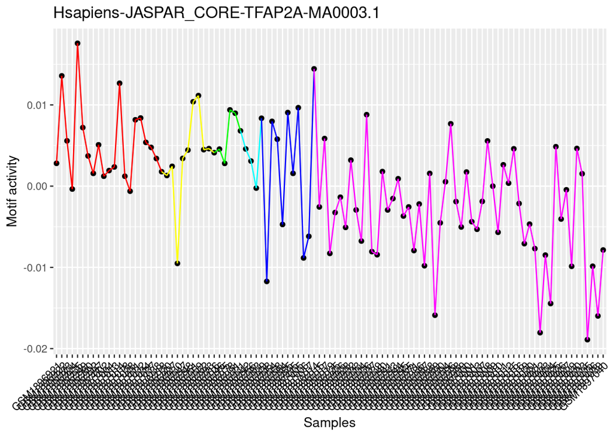

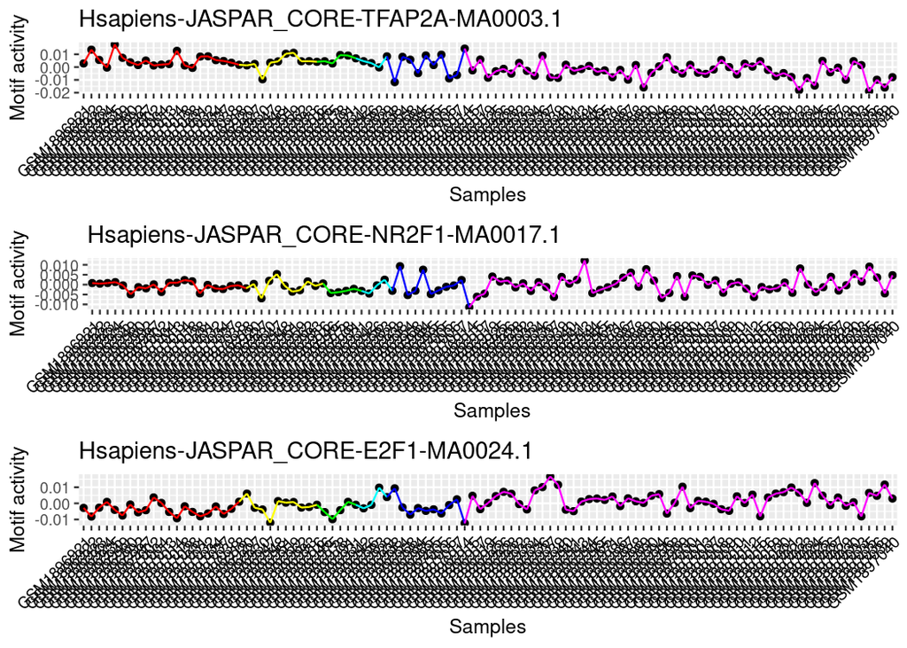

```r
ordered.stages=c("4S",
                 "1",
                  "2.1",
                  "2.2",
                  "3",
                  "4")
pheno.indx =
        order(ordered(GPL13534pheno$stage,
             levels = ordered.stages))
GPL13534pheno.ord=GPL13534pheno[pheno.indx,]


coef.ord=
  model$coef[,match(rownames(GPL13534pheno.ord),
                    colnames(model$coef))]

color.line=
  unlist(sapply(1:length(ordered.stages), function(i){
    nbr.times=sum(GPL13534pheno.ord$stage==ordered.stages[i])
    colorline1=rainbow(length(ordered.stages))[i]
    rep(colorline1, nbr.times)
  }))



plotMotifActivity("Hsapiens-JASPAR_CORE-TFAP2A-MA0003.1",
                   coef.ord,
                   colour.line=color.line
                  )


plotMotifsActivity(rownames(coef.ord)[1:3],
                   coef.ord,
                   colour.line=color.line
                  )
```

In our model TFs can act as activators or repressors. If motif activity of a TF is correlated with expression of a gene that codes this TFs across samples then the TF is predicted to act as a activator. It means if gene expression decreases across samples together with motif activity (related to decrease of DNA methylation) then most likely that TF “activates” DNA motifs on the DMRs. If the correlation is negative then the TFs is predicted to act as a repressor. We filter TFs that gene expression is correlated with motif activities values using the `filterActivityByTFexpression` function.

```r
coef.ord.renamed=coef.ord
rownames(coef.ord.renamed) = sapply(rownames(coef.ord), function(x){
                                    strsplit(x, split="-")[[1]][3]
                                     })


coef.ord.corr=
filterActivityByTFexpression(coef.ord.renamed,
                             gene.expr,
                             split.sign=NULL,
                             threshold=0.2)
```

In order to build a protein-protein interaction (PPI) network from our result TFs we use the STRING database that stores known and predicted protein–protein interactions. The `plotNetwork` function uses the **STRINGdb** R package to obtain PPI network and the **igraph** R package functionalities for visualization of the network.

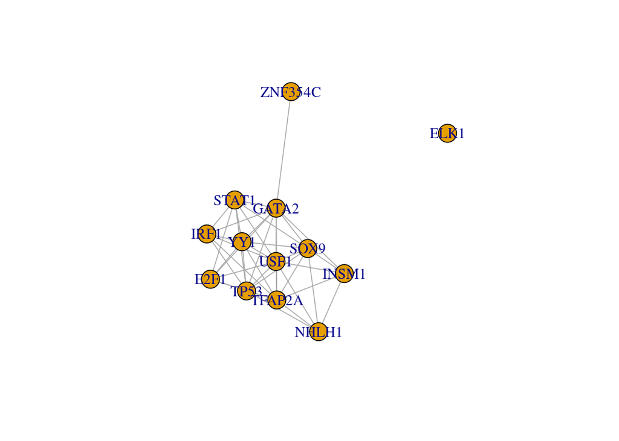

```r
library(STRINGdb)
library(igraph)
set.seed(123)
plotNetwork(coef.ord.corr$TF,
           species=9606, # human
           version="11",
           score_threshold=200,
           input_directory="./"
           #nodes.color = nodes.color,
           #layout=layout_with_fr,
           #vertex.size=100*max.signif.tf1,
           #vertex.color="darkslategray3",
           #vertex.frame.color="grey",
           #vertex.label.color="#101820FF",
           #vertex.label.color="black",
           #vertex.label.cex=0.5,
           #edge.arrow.size=50,
           #graph_sub=mnavshrnmn_graph_sub,
           #add.missing=TRUE
           )
```

Argelaguet, Ricard, Damien Arnol, Danila Bredikhin, Yonatan Deloro, Britta Velten, John C. Marioni, and Oliver Stegle. 2020. “MOFA$\mathplus$: A Statistical Framework for Comprehensive Integration of Multi-Modal Single-Cell Data.” *Genome Biology* 21 (1). https://doi.org/10.1186/s13059-020-02015-1.

Argelaguet, Ricard, Britta Velten, Damien Arnol, Sascha Dietrich, Thorsten Zenz, John C Marioni, Florian Buettner, Wolfgang Huber, and Oliver Stegle. 2018. “Multi-Omics Factor Analysisa Framework for Unsupervised Integration of Multi-Omics Data Sets.” *Molecular Systems Biology* 14 (6). https://doi.org/10.15252/msb.20178124.

Balwierz, Piotr J, Mikhail Pachkov, Phil Arnold, Andreas J Gruber, Mihaela Zavolan, and Erik van Nimwegen. 2014. “ISMARA: Automated Modeling of Genomic Signals as a Democracy of Regulatory Motifs.” *Genome Res.* 24 (5): 869–84.

Consortium, The ENCODE Project. 2012. “An Integrated Encyclopedia of DNA Elements in the Human Genome.” *Nature* 489 (7414): 57–74. https://doi.org/10.1038/nature11247.

Consortium, The FANTOM, and Riken Omics Science Center. 2009. “The Transcriptional Network That Controls Growth Arrest and Differentiation in a Human Myeloid Leukemia Cell Line.” *Nature Genetics* 41 (5): 553–62. https://doi.org/10.1038/ng.375.

Dhaeseleer, Patrik. 2006. “What Are DNA Sequence Motifs?” *Nature Biotechnology* 24 (4): 423–25. https://doi.org/10.1038/nbt0406-423.

Dhingra Priyanka, Martinez-Fundichely A, Liu Eric Minwei, and Khurana Ekta. 2017. “Integration of Genetic and Epigenetic Alterations with Tissue-Specific Network Reveals Regulatory Drivers of Prostate Cancer.” Zenodo. https://doi.org/10.5281/ZENODO.800729.

Gama-Castro, Socorro, Heladia Salgado, Alberto Santos-Zavaleta, Daniela Ledezma-Tejeida, Luis Muñiz-Rascado, Jair Santiago Garcı́a-Sotelo, Kevin Alquicira-Hernández, et al. 2016. “RegulonDB Version 9.0: High-Level Integration of Gene Regulation, Coexpression, Motif Clustering and Beyond.” *Nucleic Acids Res.* 44 (D1): D133–43.

Grant, Charles E, Timothy L Bailey, and William Stafford Noble. 2011. “FIMO: Scanning for Occurrences of a Given Motif.” *Bioinformatics* 27 (7): 1017–18.

Heinz, Sven, Christopher Benner, Nathanael Spann, Eric Bertolino, Yin C Lin, Peter Laslo, Jason X Cheng, Cornelis Murre, Harinder Singh, and Christopher K Glass. 2010. “Simple Combinations of Lineage-Determining Transcription Factors Prime Cis-Regulatory Elements Required for Macrophage and B Cell Identities.” *Molecular Cell*.

Jankowski, Aleksander, Jerzy Tiuryn, and Shyam Prabhakar. 2016. “Romulus: Robust Multi-State Identification of Transcription Factor Binding Sites from DNase-seq Data.” *Bioinformatics*.

Jiao, Yinming, Martin Widschwendter, and Andrew E. Teschendorff. 2014. “A Systems-Level Integrative Framework for Genome-Wide DNA Methylation and Gene Expression Data Identifies Differential Gene Expression Modules Under Epigenetic Control.” *Bioinformatics* 30 (16): 2360–66. https://doi.org/10.1093/bioinformatics/btu316.

Kel, A E, E Gössling, I Reuter, E Cheremushkin, O V Kel-Margoulis, and E Wingender. 2003. “MATCH: A Tool for Searching Transcription Factor Binding Sites in DNA Sequences.” *Nucleic Acids Res.* 31 (13): 3576–79.

Kopp, Wolfgang, Remo Monti, Annalaura Tamburrini, Uwe Ohler, and Altuna Akalin. 2020. “Deep Learning for Genomics Using Janggu.” *Nature Communications* 11 (1). https://doi.org/10.1038/s41467-020-17155-y.

Kundaje, Anshul, Wouter Meuleman, Jason Ernst, Misha Bilenky, Angela Yen, Alireza Heravi-Moussavi, Pouya Kheradpour, et al. 2015. “Integrative Analysis of 111 Reference Human Epigenomes.” *Nature* 518 (7539): 317–30. https://doi.org/10.1038/nature14248.

Lambert, Samuel A., Arttu Jolma, Laura F. Campitelli, Pratyush K. Das, Yimeng Yin, Mihai Albu, Xiaoting Chen, Jussi Taipale, Timothy R. Hughes, and Matthew T. Weirauch. 2018. “The Human Transcription Factors.” *Cell* 172 (4): 650–65. https://doi.org/10.1016/j.cell.2018.01.029.

Lederer, Simone, Tom Heskes, Simon J. van Heeringen, and Cornelis A. Albers. 2020. “Investigating the Effect of Dependence Between Conditions with Bayesian Linear Mixed Models for Motif Activity Analysis.” Edited by Sushmita Roy. *PLOS ONE* 15 (5): e0231824. https://doi.org/10.1371/journal.pone.0231824.

Madsen, Jesper Grud Skat, Alexander Rauch, Elvira Laila Van Hauwaert, Søren Fisker Schmidt, Marc Winnefeld, and Susanne Mandrup. 2018. “Integrated Analysis of Motif Activity and Gene Expression Changes of Transcription Factors.” *Genome Res.* 28 (2): 243–55.

Osmanbeyoglu, Hatice U., Raphael Pelossof, Jacqueline F. Bromberg, and Christina S. Leslie. 2014. “Linking Signaling Pathways to Transcriptional Programs in Breast Cancer.” *Genome Research* 24 (11): 1869–80. https://doi.org/10.1101/gr.173039.114.

Rhie, Suhn Kyong, Yu Guo, Yu Gyoung Tak, Lijing Yao, Hui Shen, Gerhard A. Coetzee, Peter W. Laird, and Peggy J. Farnham. 2016. “Identification of Activated Enhancers and Linked Transcription Factors in Breast, Prostate, and Kidney Tumors by Tracing Enhancer Networks Using Epigenetic Traits.” *Epigenetics & Chromatin* 9 (1). https://doi.org/10.1186/s13072-016-0102-4.

Ronen, Jonathan, Sikander Hayat, and Altuna Akalin. 2019. “Evaluation of Colorectal Cancer Subtypes and Cell Lines Using Deep Learning” 2 (6): e201900517. https://doi.org/10.26508/lsa.201900517.

Sandelin, Albin, Wynand Alkema, Pär Engström, Wyeth W. Wasserman, and Boris Lenhard. 2004. “JASPAR: an open‐access database for eukaryotic transcription factor binding profiles.” *Nucleic Acids Research* 32 (January): D91–94. https://doi.org/10.1093/nar/gkh012.

Shen, Ronglai, Adam B. Olshen, and Marc Ladanyi. 2009. “Integrative Clustering of Multiple Genomic Data Types Using a Joint Latent Variable Model with Application to Breast and Lung Cancer Subtype Analysis.” *Bioinformatics* 25 (22): 2906–12. https://doi.org/10.1093/bioinformatics/btp543.

Silva, Tiago C, Simon G Coetzee, Nicole Gull, Lijing Yao, Dennis J Hazelett, Houtan Noushmehr, De-Chen Lin, and Benjamin P Berman. 2018. “ELMER v.2: An r/Bioconductor Package to Reconstruct Gene Regulatory Networks from DNA Methylation and Transcriptome Profiles.” Edited by Oliver Stegle. *Bioinformatics* 35 (11): 1974–77. https://doi.org/10.1093/bioinformatics/bty902.

Stadler, Michael B, Rabih Murr, Lukas Burger, Robert Ivanek, Florian Lienert, Anne Schöler, Erik van Nimwegen, et al. 2011. “DNA-binding Factors Shape the Mouse Methylome at Distal Regulatory Regions.” *Nature* 480 (7378): 490–95.

Subramanian, A., P. Tamayo, V. K. Mootha, S. Mukherjee, B. L. Ebert, M. A. Gillette, A. Paulovich, et al. 2005. “Gene Set Enrichment Analysis: A Knowledge-Based Approach for Interpreting Genome-Wide Expression Profiles.” *Proceedings of the National Academy of Sciences* 102 (43): 15545–50. https://doi.org/10.1073/pnas.0506580102.

Tan, Ge, and Boris Lenhard. 2016. “TFBSTools: An r/Bioconductor Package for Transcription Factor Binding Site Analysis.” *Bioinformatics*.

Teschendorff, Andrew E., Zhen Yang, Andrew Wong, Christodoulos P. Pipinikas, Yinming Jiao, Allison Jones, Shahzia Anjum, et al. 2015. “Correlation of Smoking-Associated DNA Methylation Changes in Buccal Cells with DNA Methylation Changes in Epithelial Cancer.” *JAMA Oncology* 1 (4): 476. https://doi.org/10.1001/jamaoncol.2015.1053.

Wijetunga, N. Ari, Andrew D. Johnston, Ryo Maekawa, Fabien Delahaye, Netha Ulahannan, Kami Kim, and John M. Greally. 2017. “SMITE: An r/Bioconductor Package That Identifies Network Modules by Integrating Genomic and Epigenomic Information.” *BMC Bioinformatics* 18 (1). https://doi.org/10.1186/s12859-017-1477-3.

Wreczycka, Katarzyna, Vedran Franke, Bora Uyar, Ricardo Wurmus, Selman Bulut, Baris Tursun, and Altuna Akalin. 2019. “HOT or Not: Examining the Basis of High-Occupancy Target Regions.” *Nucleic Acids Res.* 47 (11): 5735–45.

Yin, Yimeng, Ekaterina Morgunova, Arttu Jolma, Eevi Kaasinen, Biswajyoti Sahu, Syed Khund-Sayeed, Pratyush K. Das, et al. 2017. “Impact of Cytosine Methylation on DNA Binding Specificities of Human Transcription Factors.” *Science* 356 (6337): eaaj2239. https://doi.org/10.1126/science.aaj2239.

Yuan, Tian, Yinming Jiao, Simone de Jong, Roel A. Ophoff, Stephan Beck, and Andrew E. Teschendorff. 2015. “An Integrative Multi-Scale Analysis of the Dynamic DNA Methylation Landscape in Aging.” Edited by John M. Greally. *PLOS Genetics* 11 (2): e1004996. https://doi.org/10.1371/journal.pgen.1004996.

Zhang, Shihua, Chun-Chi Liu, Wenyuan Li, Hui Shen, Peter W. Laird, and Xianghong Jasmine Zhou. 2012. “Discovery of Multi-Dimensional Modules by Integrative Analysis of Cancer Genomic Data.” *Nucleic Acids Research* 40 (19): 9379–91. https://doi.org/10.1093/nar/gks725.

Zhong, Shan, Xin He, and Ziv Bar-Joseph. 2013. “Predicting Tissue Specific Transcription Factor Binding Sites.” *BMC Genomics* 14 (November): 796.